# The Effect of Youth Unemployment on Youth Political Engagement

12/2/2016

## Research Question

- How does youth unemployment affect youth political engagement within European countries?
- Does it inspire **apathy** or **action**?

**Hypothesis:** Higher youth unemployment will lead to greater levels of interest and engagement in politics.

## Data Sources

**The European Social Survey**

- Representative survey of EU residents conducted every two years (we used data from 2002 - 2012)
- Respondents are asked about their opinions and attitudes on a variety of political and social topics
- Subsetted data to only look at youths 18 - 25

**Eurostat Data**

- Used their data on yearly youth unemployment rates in various European countries

## Overview: Unemployment Levels 2008 & 2010

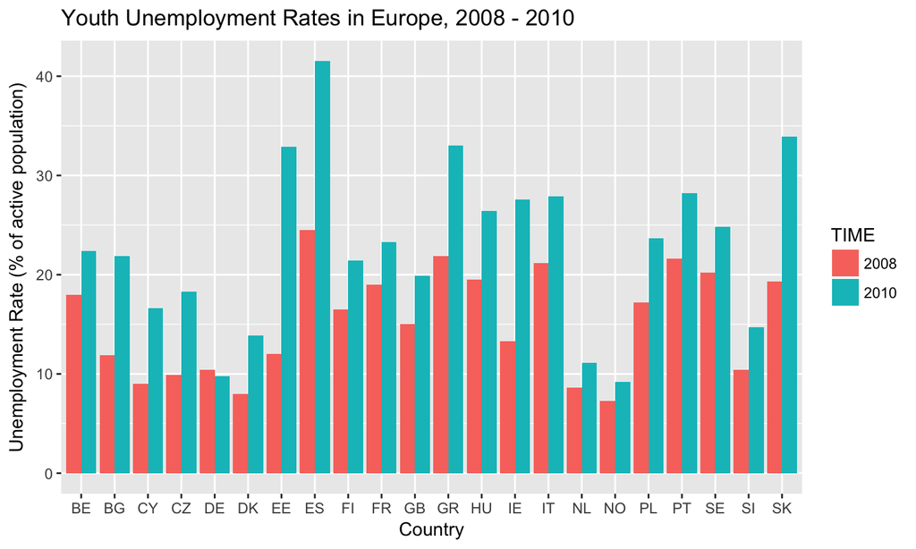

## Trends in Political Interest Across Countries

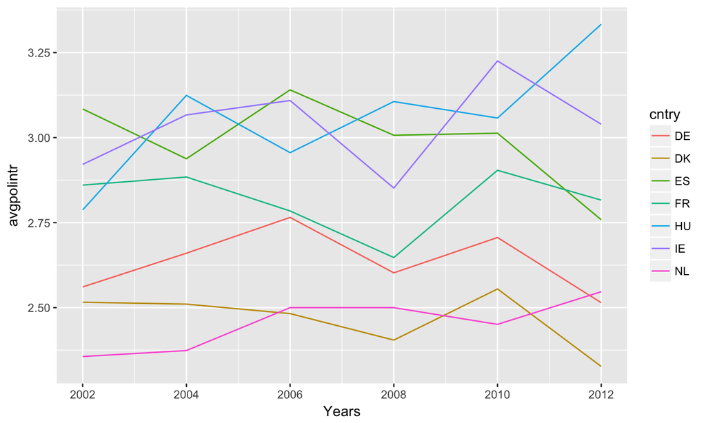

## Trends in Political Interest Across Education Levels

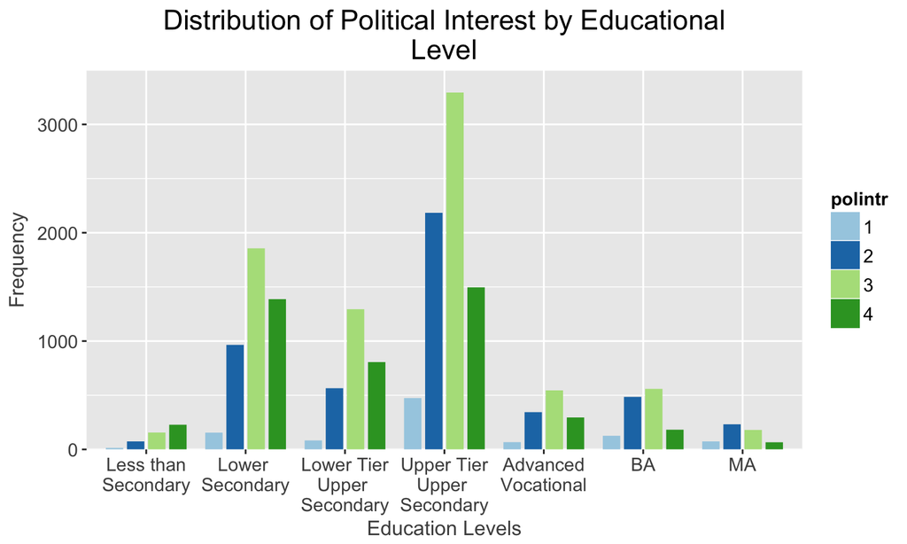

## Inferential Statistics I: Initial Attempt

- Original intent was to regress the change in a given political variable on the change in unemployment
- Became clear we simply didn't have the right data / enough data to do this meaningfully

|  | *Dependent variable:* |
| --- | --- |
|  | deltaavgpolintr |
| Delta Unemployment | 0.002 |
|  | (0.003) |
| Constant | 0.004 |
|  | (0.022) |
| Observations | 60 |
| R<sup>2</sup> | 0.010 |
| Adjusted R<sup>2</sup> | -0.007 |
| Residual Std. Error | 0.155 (df = 58) |
| F Statistic | 0.582 (df = 1; 58) |
| *Note:* | p<0.1; p<0.05; p<0.01 |

|  | *Dependent variable:* |
| --- | --- |
|  | deltaavgvote |
| Delta Unemployment | 0.0003 |
|  | (0.002) |
| Constant | -0.006 |
|  | (0.014) |
| Observations | 60 |
| R<sup>2</sup> | 0.0004 |
| Adjusted R<sup>2</sup> | -0.017 |
| Residual Std. Error | 0.098 (df = 58) |
| F Statistic | 0.022 (df = 1; 58) |
| *Note:* | p<0.1; p<0.05; p<0.01 |

## Inferential Statistics II: Individual-Level Analysis

- Decided to look at individual-level ESS data instead for additional insight

Survey asks people for their employment status

- Within the paper, would like to look at at least three different measurements for political engagement

Level of political interest

Participation in public demonstrations

Voting

- For this presentation, will focus on **political interest**

## Inferential Statistics III: Political Interest

|  | *Dependent variable:* |  |  |
| --- | --- | --- | --- |
|  | polintr |  |  |
|  | (1) | (2) | (3) |
| Unemployment | 0.220*** | 0.193*** | 0.206*** |
|  | (0.017) | (0.019) | (0.019) |
| Gender |  | 0.175*** | 0.170*** |
|  |  | (0.012) | (0.012) |
| Less than secondary |  | 3.149*** |  |
|  |  | (0.040) |  |
| Lower secondary |  | 2.933*** |  |
|  |  | (0.014) |  |
| L. Tier Upper Secondary |  | 2.948*** |  |
|  |  | (0.017) |  |
| U. Tier Upper Secondary |  | 2.688*** |  |
|  |  | (0.012) |  |
| Advanced Vocational |  | 2.766*** |  |
|  |  | (0.024) |  |
| BA |  | 2.482*** |  |
|  |  | (0.024) |  |
| MA |  | 2.326*** |  |
|  |  | (0.036) |  |
| eisced |  |  | -0.118*** |
|  |  |  | (0.005) |
| uniondummy |  | -0.154*** | -0.143*** |
|  |  | (0.019) | (0.019) |
| Constant | 2.843*** |  | 3.201*** |
|  | (0.006) |  | (0.018) |
| Observations | 24,143 | 17,927 | 17,927 |
| R<sup>2</sup> | 0.007 | 0.925 | 0.055 |
| Adjusted R<sup>2</sup> | 0.007 | 0.925 | 0.054 |
| Residual Std. Error | 0.850 (df = 24141) | 0.819 (df = 17917) | 0.821 (df = 17922) |
| F Statistic | 169.784*** (df = 1; 24141) | 22,149.620*** (df = 10; 17917) | 258.622*** (df = 4; 17922) |
| *Note:* | p<0.1; p<0.05; p<0.01 |  |  |

## Inferential Statistics III: Political Interest

|  | *Dependent variable:* |
| --- | --- |
|  | polintr |
| unempdummy | 0.15*** |
|  | (0.02) |
| gndr | 0.17*** |
|  | (0.01) |
| eisced | -0.13*** |
|  | (0.005) |
| uniondummy | 0.02 |
|  | (0.02) |
| factor(cntry)BE | 3.22*** |
|  | (0.03) |
| factor(cntry)BG | 3.40*** |
|  | (0.05) |
| factor(cntry)CY | 3.61*** |
|  | (0.06) |
| factor(cntry)CZ | 3.73*** |
|  | (0.03) |
| factor(cntry)DE | 2.97*** |
|  | (0.02) |
| factor(cntry)DK | 2.78*** |
|  | (0.03) |
| factor(cntry)EE | 3.27*** |
|  | (0.03) |
| factor(cntry)ES | 3.38*** |
|  | (0.03) |
| factor(cntry)FI | 3.07*** |
|  | (0.04) |
| factor(cntry)FR | 3.18*** |
|  | (0.04) |
| factor(cntry)GB | 3.21*** |
|  | (0.04) |
| factor(cntry)GR | 3.58*** |
|  | (0.05) |
| factor(cntry)HU | 3.44*** |
|  | (0.03) |
| factor(cntry)IE | 3.56*** |
|  | (0.04) |
| factor(cntry)IT | 3.07*** |
|  | (0.08) |
| factor(cntry)NL | 2.82*** |
|  | (0.03) |
| factor(cntry)NO | 3.20*** |
|  | (0.03) |
| factor(cntry)PL | 3.27*** |
|  | (0.03) |
| factor(cntry)PT | 3.38*** |
|  | (0.04) |
| factor(cntry)SE | 2.99*** |
|  | (0.04) |
| factor(cntry)SI | 3.30*** |
|  | (0.03) |
| factor(cntry)SK | 3.37*** |
|  | (0.03) |
| Observations | 17,927 |
| R<sup>2</sup> | 0.93 |
| Adjusted R<sup>2</sup> | 0.93 |
| Residual Std. Error | 0.79 (df = 17901) |
| F Statistic | 9,206.28*** (df = 26; 17901) |
| *Note:* | p<0.1; p<0.05; p<0.01 |

## Inferential Statistics III: Political Interest

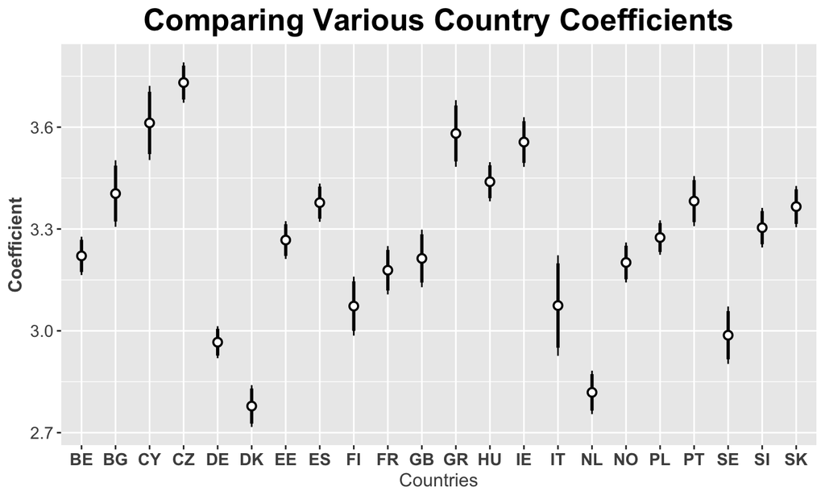

Remember, a lower number (i.e., closer to 1) equates to a higher political interest.

## Concluding Thoughts

- An unemployed young person will have a lower political interest than an employed young person
- At higher levels of education, individuals indicate higher political interest
- A person's country of residence also clearly affects their level of political interest

This conditions the effect of unemployment on political interest

## Where to from here?

- **Want to introduce new types of models in the paper**

Will likely need to make use of logit models when analyzing voting and demonstration habits

- **Integration of additional data**

There is a 7th round of ESS data that we were unable to successfully merge with our current dataset

Would like to continue to work on this to increase the range of data available to us

## Thank you!

Questions?

## Data Sources

ESS Data: http://www.europeansocialsurvey.org/downloadwizard/

Eurostat Data: http://ec.europa.eu/eurostat/web/lfs/data/database ("Unemployment by sex and age - annual average")